# Grain Boundary Search Task (V1) EDA

Dave Braun

10/21/2021

This document was last updated at 2022-02-08 15:15:41.

## What do we want to look at?

- Why did Nick’s participants take so much longer than Lily’s?
  - Somewhat captured in the plots already produced
- IVs:
  - Possible line widths
  - Location of lines
  - Line orientation
- DVs:
  - Accuracy
  - RT
  - Choice
  - Order of line selection
- How does accuracy change over line selections and de selections

## Line orientation

This is not simple.

What we need:  
* The final three lines they selected  
* The widths and orientations of all possible thinnest lines they could’ve selected  
* With those two sets, calculate hits, misses, false alarms

```r
d <- read.csv('../../data/exp1_long_data.csv')
## THINNEST LINES IS BROKEN
thinnest_lines <- read.csv('../../data/thinnest_lines.csv')
line_data <- read.csv('../../data/exp1_line_data.csv')
head(d)
```

|  | participant | date | overall_time | trial_count | click_order | prompt_rt_sec | selection_rt_ms | pressed_object | line_width | top_x | top_y | bottom_x | bottom_y | line_id | line_orientation | selected_or_released | accuracy | possible_thinnest_lines | is_practice | drop_marker | indecision_trial |
| --- | --- | --- | --- | --- | --- | --- | --- | --- | --- | --- | --- | --- | --- | --- | --- | --- | --- | --- | --- | --- | --- |
| 1 | 10 | 2021_Oct_01_1059 | 0 days 00:31:04.465510000 | 2 | 1 | 18.06451 | 980.533 | line | 1.3333 | -204.59657 | -99.34668 | -302.29828 | -169.02003 | r2c0_bottom_right | forward_slash | selected | NA | 3 | False | 10_2 | 0 |
| 2 | 10 | 2021_Oct_01_1059 | 0 days 00:31:05.332162000 | 2 | 2 | 18.06451 | 1847.185 | line | 1.3333 | -204.59657 | 280.00000 | -302.29828 | 210.32666 | r0c0_bottom_right | forward_slash | selected | NA | 3 | False | 10_2 | 0 |
| 3 | 10 | 2021_Oct_01_1059 | 0 days 00:31:06.467754000 | 2 | 3 | 18.06451 | 2982.777 | line | 1.0000 | 283.91202 | 210.32666 | 283.91202 | 90.32666 | r1c2_right | vertical | selected | NA | 3 | False | 10_2 | 0 |
| 4 | 10 | 2021_Oct_01_1059 | 0 days 00:31:08.071316000 | 2 | 4 | 18.06451 | 4586.339 | submit | NA | NA | NA | NA | NA |  |  |  | 1 | 3 | False | 10_2 | 0 |
| 5 | 10 | 2021_Oct_01_1059 | 0 days 00:31:59.290233000 | 4 | 1 | 10.26303 | 499.617 | line | 1.0000 | 88.50858 | 210.32666 | 88.50858 | 90.32666 | r1c1_right | vertical | selected | NA | 4 | False | 10_4 | 0 |
| 6 | 10 | 2021_Oct_01_1059 | 0 days 00:32:00.722075000 | 4 | 2 | 10.26303 | 1931.459 | line | 1.0000 | -204.59657 | 280.00000 | -106.89485 | 210.32666 | r0c1_bottom_left | back_slash | selected | NA | 4 | False | 10_4 | 0 |

```r
N <- d %>%
  group_by(participant) %>%
  summarize(n()) %>%
  nrow()
```

**There were 31 participants in this study.**

```r
source('../compute_accuracy_columns.r')

d <- calculate_accuracy_columns(d, thinnest_lines)
```

```r
## a function for spot checking accuracy coding throughout the data
spot_check <- function() {
  participant <- sample(d$participant, size = 1)
  trial <- sample(d[d$participant==participant,]$trial_count, size = 1)
  d_sub <- d[d$participant == participant & d$trial_count == trial,]
  t_sub <- thinnest_lines[thinnest_lines$participant == participant & thinnest_lines$trial_count == trial,]
  print(d_sub[,c('line_id', 'selected_or_released', 'accuracy_type')])
  print(' ')
  print(' ')
  print(t_sub[,c('line_width', 'line_id')])
}
```

```r
## summarize hits and false alarms
summary_data <- d %>%
  filter(!(is.na(accuracy_type))) %>%
  mutate(hit = ifelse(accuracy_type == 'hit', 1, 0), false_alarm = ifelse(accuracy_type == 'false_alarm', 1, 0)) %>%
  group_by(line_orientation) %>%
  summarize(hits = sum(hit), false_alarms = sum(false_alarm))
```

```r
line_data %>%
  filter(participant == 10, trial_count == 0) %>%
  group_by(line_orientation) %>%
  summarize(count = n())
```

| line_orientation | count |
| --- | --- |

```r
## summarize misses

thinnest_lines <- d %>%
  filter(pressed_object == 'submit') %>%
  select(participant, trial_count, accuracy) %>%
  inner_join(thinnest_lines)
summary_data <- thinnest_lines %>%
  filter(accuracy != 1) %>%
  group_by(line_orientation) %>%
  summarize(misses = n()) %>%
  inner_join(summary_data) %>%
  gather(accuracy_type, count, misses:false_alarms)
```

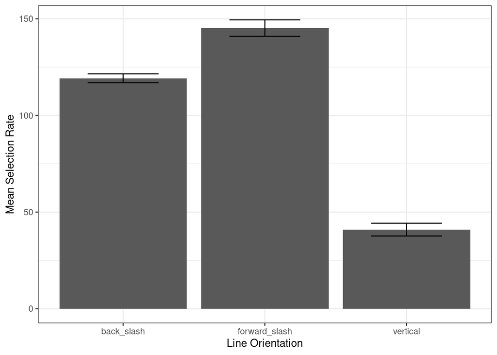

```r
d %>%
  filter(selected_or_released == 'selected') %>%
  group_by(participant, line_orientation) %>%
  summarize(count = n()) %>%
  group_by(line_orientation) %>%
  summarize(mean_selection_rate = mean(count), se = sd(count) / sqrt(length(unique(d$participant)))) %>%
  ggplot(aes(x = line_orientation, y = mean_selection_rate)) +
  geom_bar(stat = 'identity') +
  geom_errorbar(aes(ymin = mean_selection_rate - se, ymax = mean_selection_rate + se), width = .5) +
  labs(
    x = 'Line Orientation',
    y = 'Mean Selection Rate'
  ) +
  theme_bw()
```

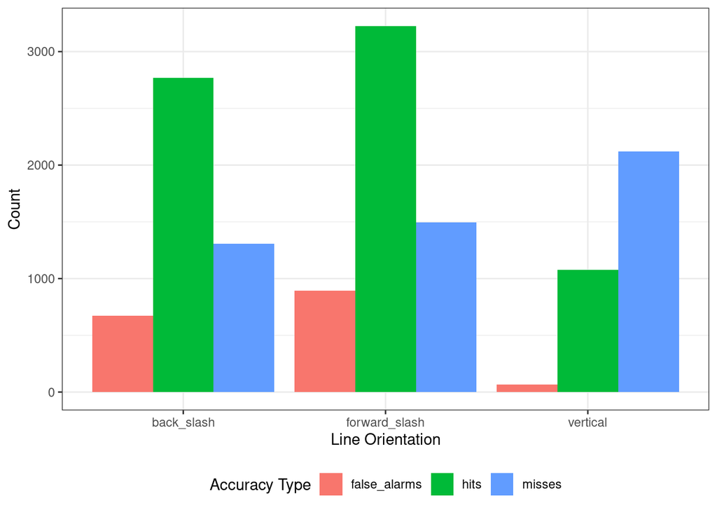

```r
summary_data %>%
  ggplot(aes(x = line_orientation, y = count)) +
  geom_bar(stat = 'identity', aes(fill = accuracy_type), position = position_dodge(width = .9)) +
  labs(
    y = 'Count',
    x = 'Line Orientation',
    fill = 'Accuracy Type'
  ) +
  theme_bw() +
  theme(legend.position = 'bottom')
```

```r
ggsave('line_orientation.png', height = 1080 / 300, width = 1920 / 300, units = 'in', dpi = 300)
```

## Quadrant Analysis

We’ll calculate the center of the grid by looking at the most extreme X’s and Y’s and taking the center, then compare the center of the lines against that center point.

```r
line_data <- read.csv('../../data/exp1_line_data.csv')
head(line_data)
```

|  | participant | date | trial_count | line_id | line_width | is_exterior | top_x | top_y | bottom_x | bottom_y | line_orientation | drop_marker |
| --- | --- | --- | --- | --- | --- | --- | --- | --- | --- | --- | --- | --- |
| 1 | 10 | 2021_Oct_01_1059 | 2 | r0c0_left | 2.333333 | True | -400.0000 | 400.0000 | -400.0000 | 280.0000 | vertical | 10_2 |
| 2 | 10 | 2021_Oct_01_1059 | 2 | r0c0_bottom_left | 2.333333 | True | -400.0000 | 280.0000 | -302.2983 | 210.3267 | back_slash | 10_2 |
| 3 | 10 | 2021_Oct_01_1059 | 2 | r0c0_bottom_right | 1.333300 | False | -204.5966 | 280.0000 | -302.2983 | 210.3267 | forward_slash | 10_2 |
| 4 | 10 | 2021_Oct_01_1059 | 2 | r0c0_right | 3.333300 | False | -204.5966 | 400.0000 | -204.5966 | 280.0000 | vertical | 10_2 |
| 5 | 10 | 2021_Oct_01_1059 | 2 | r0c0_top_right | 2.333333 | True | -302.2983 | 469.6733 | -204.5966 | 400.0000 | back_slash | 10_2 |
| 6 | 10 | 2021_Oct_01_1059 | 2 | r0c0_top_left | 2.333333 | True | -302.2983 | 469.6733 | -400.0000 | 400.0000 | forward_slash | 10_2 |

```r
top_left <- c(min(line_data$top_x), max(line_data$top_y))
top_right <- c(max(line_data$top_x), max(line_data$top_y))
bottom_left <- c(min(line_data$bottom_x), min(line_data$bottom_y))
bottom_right <- c(max(line_data$bottom_x), min(line_data$bottom_y))
print(top_left)
```

```
## [1] -400.0000  469.6733
```

```r
print(top_right)
```

```
## [1] 479.3154 469.6733
```

```r
print(bottom_left)
```

```
## [1] -400.0000 -358.6934
```

```r
print(bottom_right)
```

```
## [1]  479.3154 -358.6934
```

```r
center <- c(mean(c(top_left[1], top_right[1])), mean(c(top_left[2], bottom_left[2])))
center
```

```
## [1] 39.65772 55.48999
```

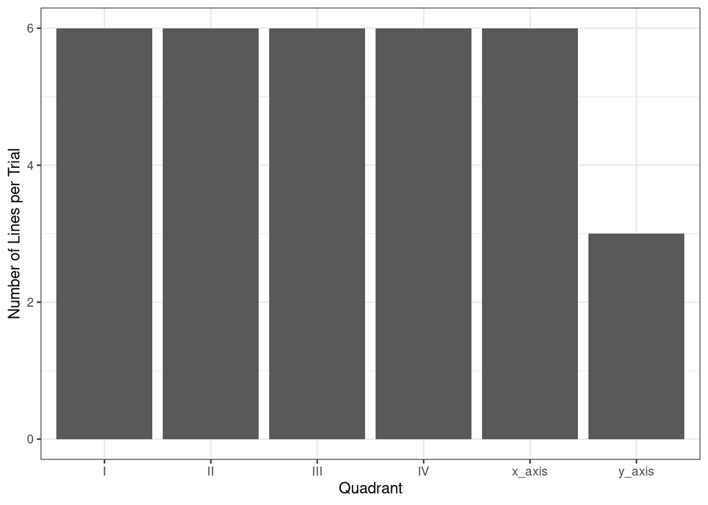

```r
## calculate line centers

d <- d %>%
  mutate(line_center_x = (top_x + bottom_x) / 2, line_center_y = (top_y + bottom_y) / 2) %>%
  mutate(quadrant = ifelse(line_center_x > center[1] & line_center_y > center[2], 'I', ifelse(line_center_x < center[1] & line_center_y > center[2], 'II',
                    ifelse(line_center_x < center[1] & line_center_y < center[2], 'III', ifelse(line_center_x > center[1] & line_center_y < center[2], 'IV', '')))))
line_data <- line_data %>%
  mutate(line_center_x = (top_x + bottom_x) / 2, line_center_y = (top_y + bottom_y) / 2) %>%
  mutate(quadrant = ifelse(line_center_x > center[1] & line_center_y > center[2], 'I', ifelse(line_center_x < center[1] & line_center_y > center[2], 'II',
                    ifelse(line_center_x < center[1] & line_center_y < center[2], 'III', ifelse(line_center_x > center[1] & line_center_y < center[2], 'IV', '')))))


line_data %>%
  filter(participant == 1, trial_count == 0, is_exterior == 'False') %>%
  mutate(x_dist = abs(line_center_x - center[1]), y_dist = abs(line_center_y - center[2])) %>%
  mutate(is_on_axis = ifelse(x_dist < 0.1, 'y_axis', ifelse(y_dist < 0.1, 'x_axis', ''))) %>%
  mutate(quadrant = ifelse(is_on_axis == '', quadrant, is_on_axis)) %>%
  group_by(quadrant) %>%
  summarize(count = n()) %>%
  ggplot(aes(x = quadrant, y = count)) +
  geom_bar(stat = 'identity') +
  labs(
    x = 'Quadrant',
    y = 'Number of Lines per Trial'
  ) +
  theme_bw()
```

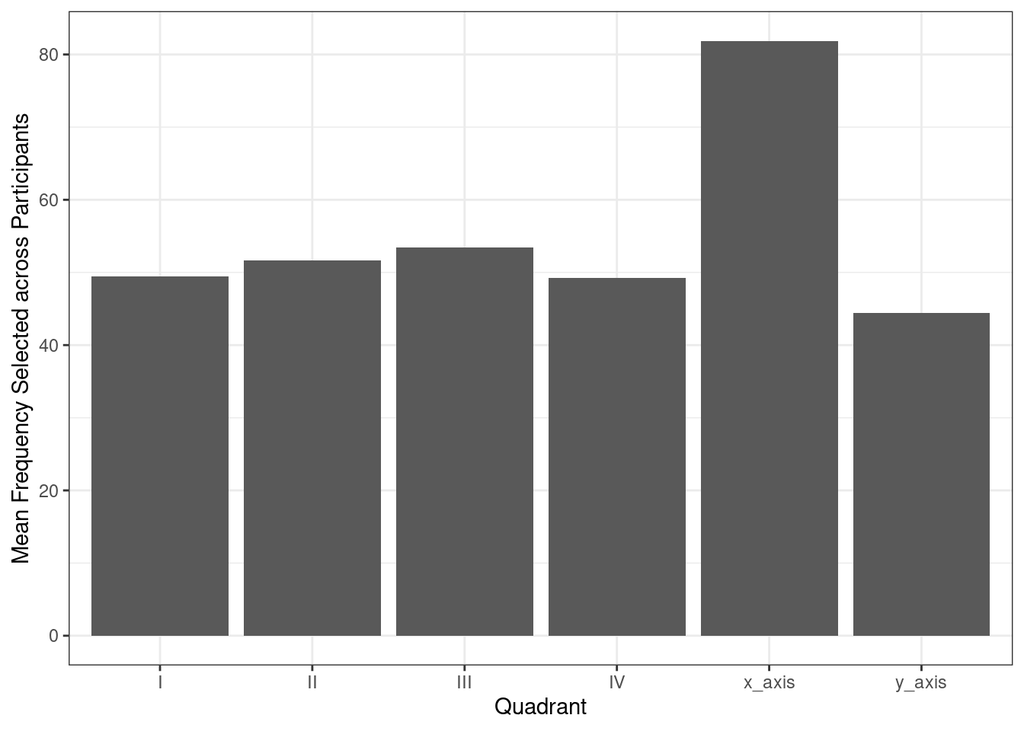

```r
ggsave('lines_per_quadrant.png', height = 1080 / 300, width = 1920 / 300, units = 'in', dpi = 300)

d <- d %>%
  mutate(x_dist = abs(line_center_x - center[1]), y_dist = abs(line_center_y - center[2])) %>%
  mutate(is_on_axis = ifelse(x_dist < 0.1, 'y_axis', ifelse(y_dist < 0.1, 'x_axis', ''))) %>%
  mutate(quadrant = ifelse(is_on_axis == '', quadrant, is_on_axis))

d %>%
  filter(!(is.na(quadrant))) %>%
  group_by(participant, quadrant) %>%
  summarize(count = n()) %>%
  group_by(quadrant) %>%
  summarize(mean_trials = mean(count)) %>%
  ggplot(aes(x = quadrant, y = mean_trials)) +
  geom_bar(stat = 'identity') +
  labs(
    x = 'Quadrant',
    y = 'Mean Frequency Selected across Participants'
  ) +
  theme_bw()
```

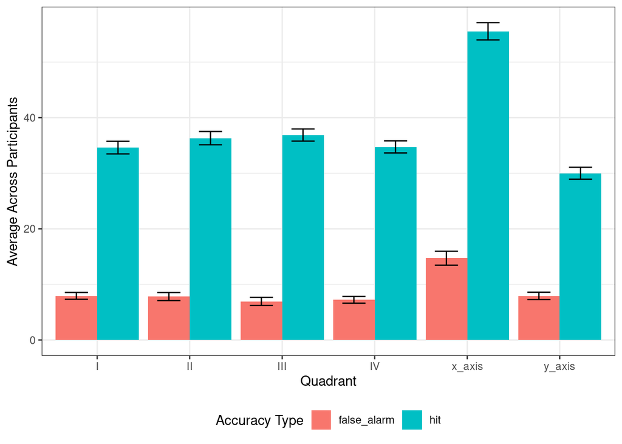

```r
ggsave('selection_by_quadrant.png', height = 1080 / 300, width = 1920 / 300, units = 'in', dpi = 300)

d %>%
  filter(!(is.na(quadrant)), !(is.na(top_x)), !(is.na(accuracy_type))) %>%
  group_by(participant, quadrant, accuracy_type) %>%
  summarize(count = n()) %>%
  group_by(quadrant, accuracy_type) %>%
  summarize(mean_count = mean(count), se_count = sd(count) / sqrt(N)) %>%
  ggplot(aes(x = quadrant, y = mean_count, group = accuracy_type)) +
  geom_bar(stat = 'identity', aes(fill = accuracy_type), position = position_dodge(width = .9)) +
  geom_errorbar(aes(ymin = mean_count - se_count, ymax = mean_count + se_count, group = accuracy_type), width = .5, position = position_dodge(.9)) +
  labs(
    x = 'Quadrant',
    y = 'Average Across Participants',
    fill = 'Accuracy Type'
  ) +
  theme_bw() +
  theme(legend.position = 'bottom')
```

```r
ggsave('accuracy_by_quadrant.png', height = 1080 / 300, width = 1920 / 300, units = 'in', dpi = 300)
```

## Features of Possible Thinnest Lines

```r
thinnest_lines_summaries <- thinnest_lines %>%
  group_by(participant, trial_count) %>%
  summarize(mean_line_width = mean(line_width), sd_line_width = sd(line_width))
head(thinnest_lines_summaries)
```

| participant | trial_count | mean_line_width | sd_line_width |
| --- | --- | --- | --- |
| 1 | 0 | 1.500000 | 0.1924886 |
| 1 | 1 | 1.500017 | 0.2789066 |
| 1 | 2 | 1.666700 | 0.0000000 |
| 1 | 3 | 1.249975 | 0.1666500 |
| 1 | 4 | 1.555567 | 0.1924886 |
| 1 | 5 | 1.600020 | 0.1491010 |

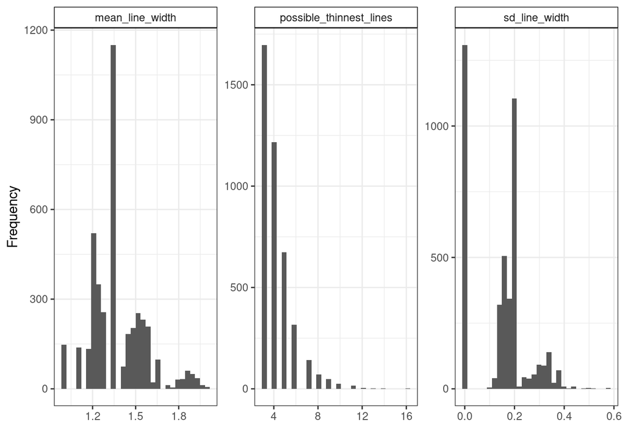

```r
plot_data <- d %>%
  group_by(participant, trial_count, accuracy_type) %>%
  summarize(count = n(), possible_thinnest_lines = max(possible_thinnest_lines)) %>%
  filter(!(is.na(accuracy_type))) %>%
  inner_join(thinnest_lines_summaries)
plot_data %>%
  gather(variable, value, possible_thinnest_lines:sd_line_width) %>%
  ggplot(aes(x = value)) +
  geom_histogram() +
  facet_wrap(~variable, scales = 'free') +
  labs(
    x = '',
    y = 'Frequency'
  ) +
  theme_bw() +
  theme(strip.background = element_rect(color = 'black', fill = 'white'))
```

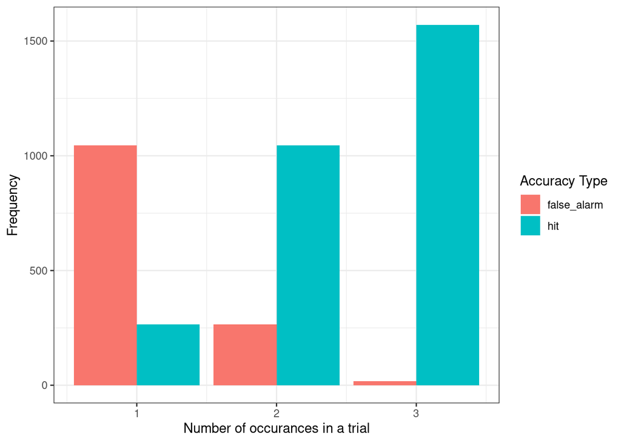

```r
plot_data %>%
  #filter(possible_thinnest_lines < 4) %>%
  group_by(accuracy_type, count) %>%
  summarize(frequency = n()) %>%
  ggplot(aes(x = count, y = frequency)) +
  geom_bar(stat = 'identity', aes(fill = accuracy_type), position = position_dodge(width = .9)) +
  labs(
    x = 'Number of occurances in a trial',
    y = 'Frequency',
    fill = 'Accuracy Type'
  ) +
  theme_bw()
```

```r
plot_data <- plot_data %>%
  spread(accuracy_type, count) %>%
  mutate(false_alarm = replace_na(false_alarm, 0),
         hit = replace_na(hit, 0),
         miss = ifelse(hit == 3, 0, possible_thinnest_lines - hit),
         correct_reject = (33 - false_alarm) - possible_thinnest_lines) %>%
  mutate(d_prime = dprime(n_hit = hit, n_fa = false_alarm, n_miss = miss, n_cr = correct_reject)$dprime)
```

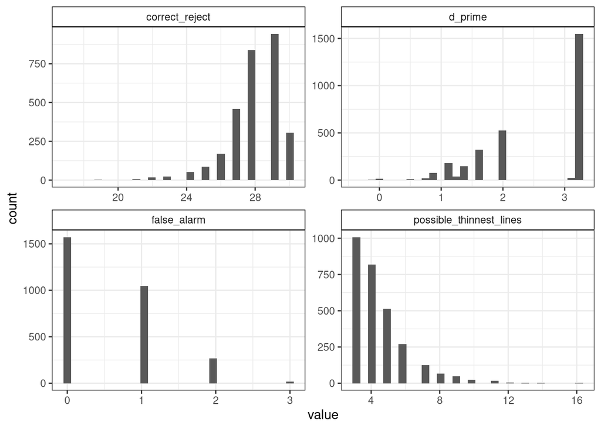

```r
## average mean line width and d' to participant level and correlate

plot_data %>%
  gather(var, value, false_alarm, correct_reject, possible_thinnest_lines, d_prime) %>%
  ggplot(aes(x = value)) +
  geom_histogram() +
  facet_wrap(~var, scales = 'free') +
  theme_bw() +
  theme(strip.background = element_rect(color = 'black', fill = 'white'))
```

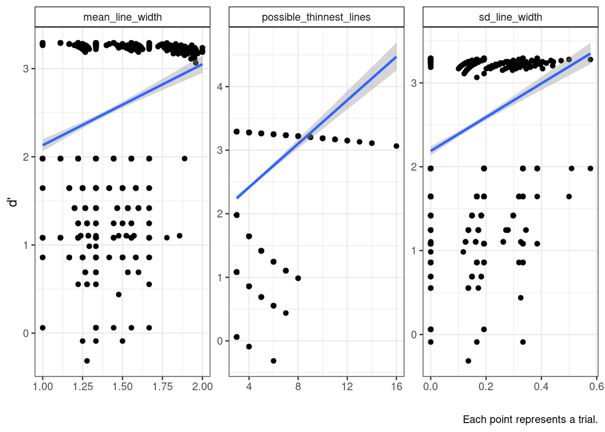

```r
plot_data %>%
  gather(var, value, mean_line_width, sd_line_width, possible_thinnest_lines) %>%
  ggplot(aes(x = value, y = d_prime)) +
  geom_point() +
  geom_smooth(method = 'lm') +
  facet_wrap(~var, scales = 'free') +
  labs(
    x = '',
    y = "d'",
    caption = 'Each point represents a trial.'
  ) +
  theme_bw() +
  theme(strip.background = element_rect(color = 'black', fill = 'white'))
```

Try to look at the relationship between mean line width and d’ while controlling for possible thinnest lines.

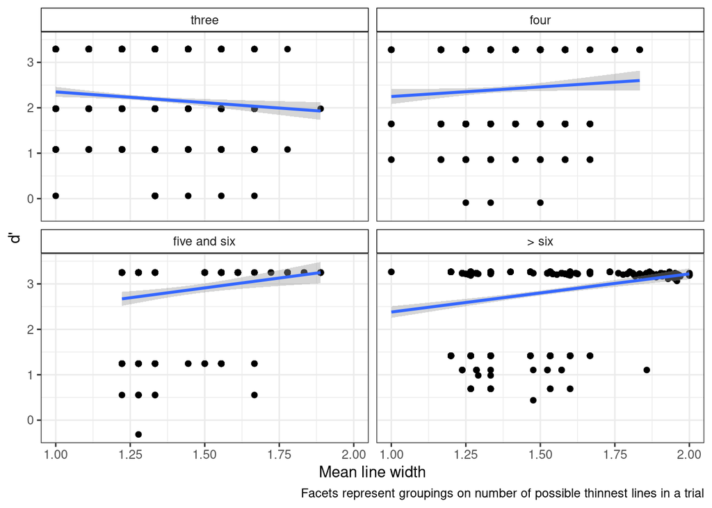

```r
plot_data %>%
  mutate(possible_thinnest_lines_bin = ifelse(possible_thinnest_lines == 3, 'three', ifelse(possible_thinnest_lines == 4, 'four', ifelse(possible_thinnest_lines > 5 & possible_thinnest_lines < 7, 'five and six', '> six')))) %>%
  mutate(possible_thinnest_lines_bin = factor(possible_thinnest_lines_bin, levels = c('three', 'four', 'five and six', '> six'))) %>%
  ggplot(aes(x = mean_line_width, y = d_prime)) +
  geom_point() +
  geom_smooth(method = 'lm') +
  facet_wrap(~possible_thinnest_lines_bin) +
  labs(
    x = 'Mean line width',
    y = "d'",
    caption = 'Facets represent groupings on number of possible thinnest lines in a trial'
  ) +
  theme_bw() +
  theme(strip.background = element_rect(color = 'black', fill = 'white'))
```

A work by [Dave Braun](https://davebraun.net)

*dab414@lehigh.edu*